# Contributions to Candidates for the Presidential Election 2016 in Maryland

Jonas Sternisko

January 29, 2018

## Dataset

I choose to work on the suggested data for the presidential election in the US in 2016. The election is quite different from what we do in my home country and I have heard that financial contributions play a major role, so I am curious what information the data may hold.

### Preparation

As stated in the dataset description it’s sufficient to work with only one state. I choose the dataset from Maryland (MD). Some of the datasets contain obsolete commas on the end of each line. To get around this, I added the same obsolete comma to the header line. Then the data can be loaded.

To ease further analysis and shorten graph labels the candidate surnames are used.

The variable of the receipt date is present as string. It needs to be transformed to a UTC date so that we can further analyse it.

The ZIP code is not in a generic format. For later investigation, we only care about the first five digits. The conversion uses the `zipcodes` library.

For later analysis, the data needs to be extended by the party of the candidate. First, get all distinct candidates and then create a table with candidate and respective party using Wikipedia as source:

- https://en.wikipedia.org/wiki/Republican_Party_presidential_candidates,_2016
- https://en.wikipedia.org/wiki/Democratic_Party_presidential_candidates,_2016
- https://en.wikipedia.org/wiki/United_States_third-party_and_independent_presidential_candidates,_2016

This can be used to extend the `contributions` dataset by joining with the party table.

Now there is a new variable `party` in the data. Later we can group the data according to this variable and analyse the different partitions.

## Exploratory Analysis

The present dataset consists of 183279 contributions registered by the Federal Election Commission. Lets explore the meaning and distribution of the different variables. First, I inspect the data using `head(contributions)`, `names(contributions)` and RStudio’s overview.

The variables `cand_id` seem to refer to an id of the candidate name `cand_nm`, which is more human readable than the former so I will not pursue `cand_id` any further. Likewise, the variables `receipt_desc`, `memo_cd`, `memo_text`, `form_tp`, `file_num`, `tran_id` seem to refer to the way or extra information the contributions are registered at the Federal Election Commission. I will not investigate these either. Thus, the following variables remain:

- candidate
  - `cand_nm`
- contributor
  - `contbr_nm` name
  - `contbr_city` city
  - `contbr_st` state
  - `contbr_zip` postal code
  - `contbr_employer` employer
  - `contbr_occupation` occupation
- Contribution receipt
  - `contb_receipt_date` date
  - `contb_receipt_amt` amount
- Election
  - `election_tp` year and type of the election (e.g. general election). Year should be always 2016 in this dataset.

### Candidates

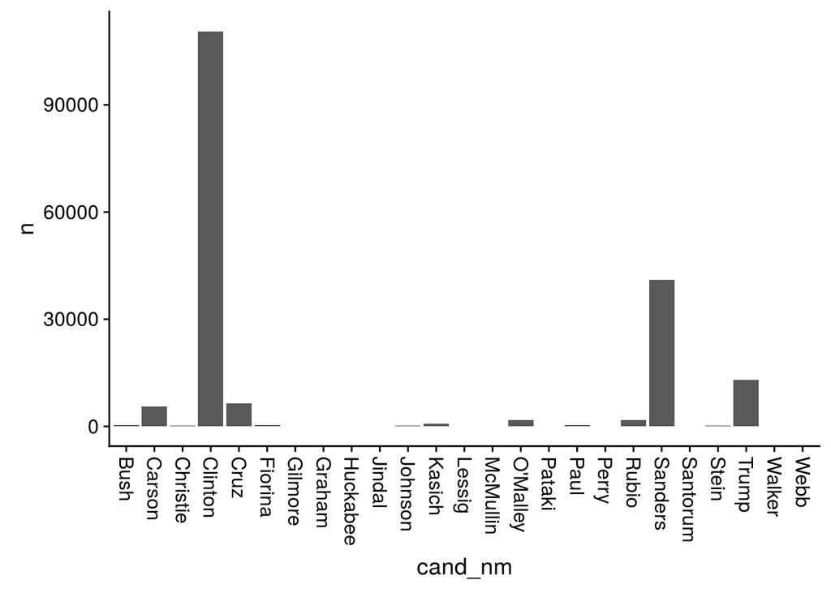

This already gives and idea, that most contributions in Maryland were given to Hillary Clinton. But is this also true for the total amount contributed for each individual campaign?

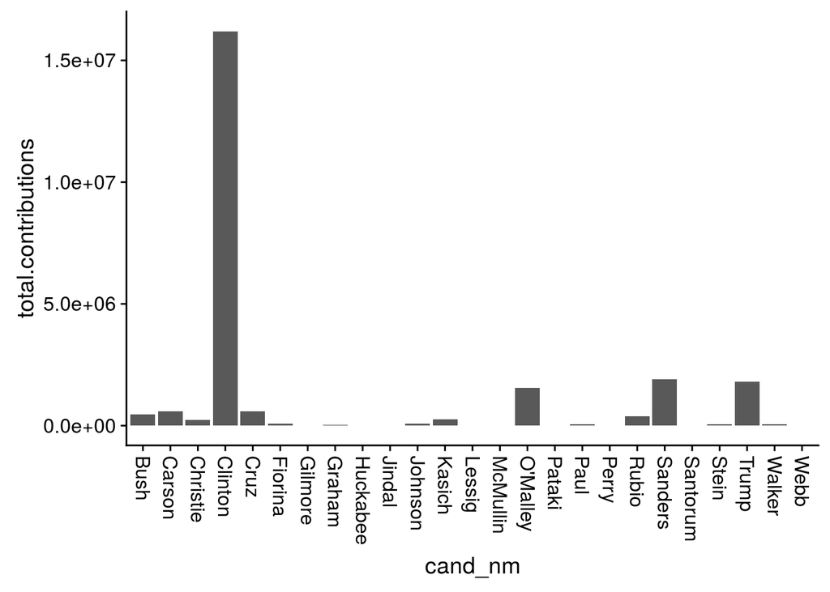

The leader is still the same (Hillary Clinton), but below there are differences. O’Malley, Sanders and Trump are head to head regarding the total amount contributed to each of their campaigns. This requires a deeper look into how much has been contributed in average.

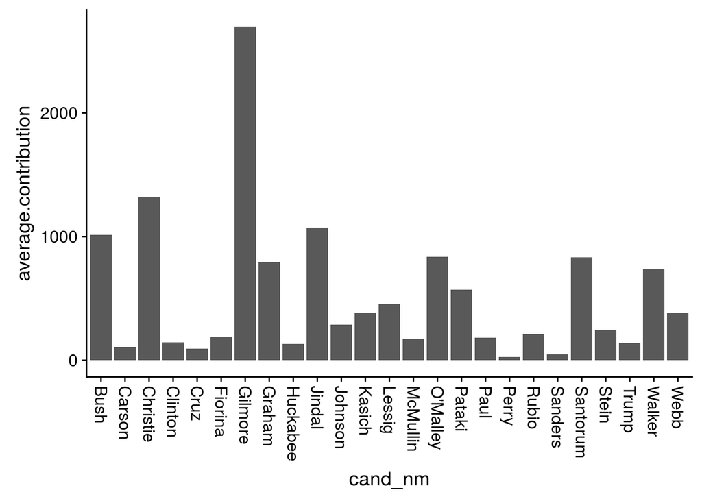

Interestingly, the candidates who had the most contributions to their campaign, had the lowest contribution in average. The reason for this might be that when starting to campaign, the campaign organizers try to get convince big supporters which contribute large individual amounts and only later on, when the campaign has enough chance to succeed, try to raise contributions from the broader public, where contributions are typically smaller in average.

Lets compare again the number of contributions and total amount contributed.

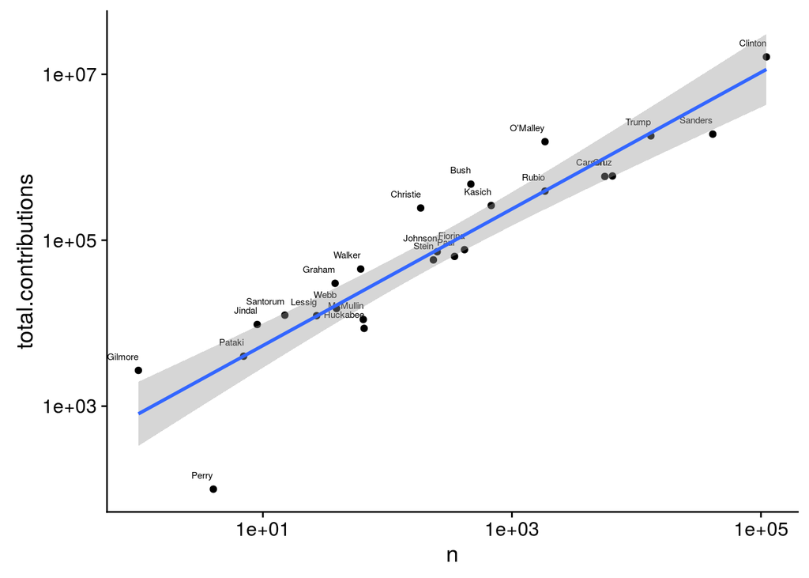

Interestingly, most data points fall along a line when both x and y axes use logarithmic scale. Just the donations for Rick Perry fall off a lot from this. Thus the data shows the obvious: The more individual contributions you get, the higher the total amount contributed to your campaign.

Maybe we come back to this later and check the distributions of the amounts per candidate, but for now I don’t want to dive too deep into this.

### Date

Lets investigate when people contributed. We can create a histogram for the dates:

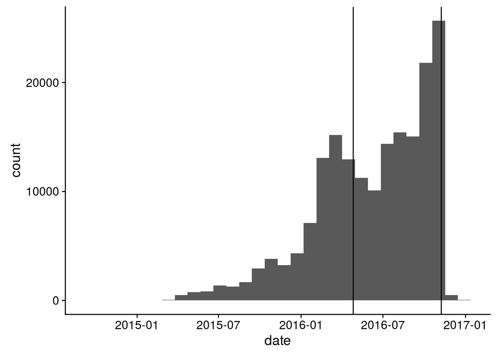

Lets check if contributors have a weekday on which they pledge to their candidate:

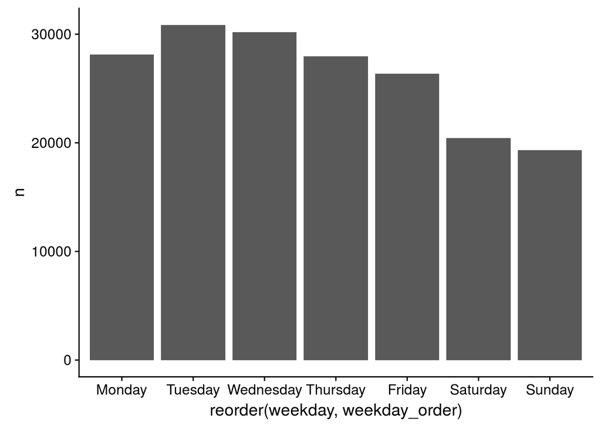

Contributing to political campaigns seems to be a professional thing, people do it less on Saturday or Sunday.

### Contributors

#### By city

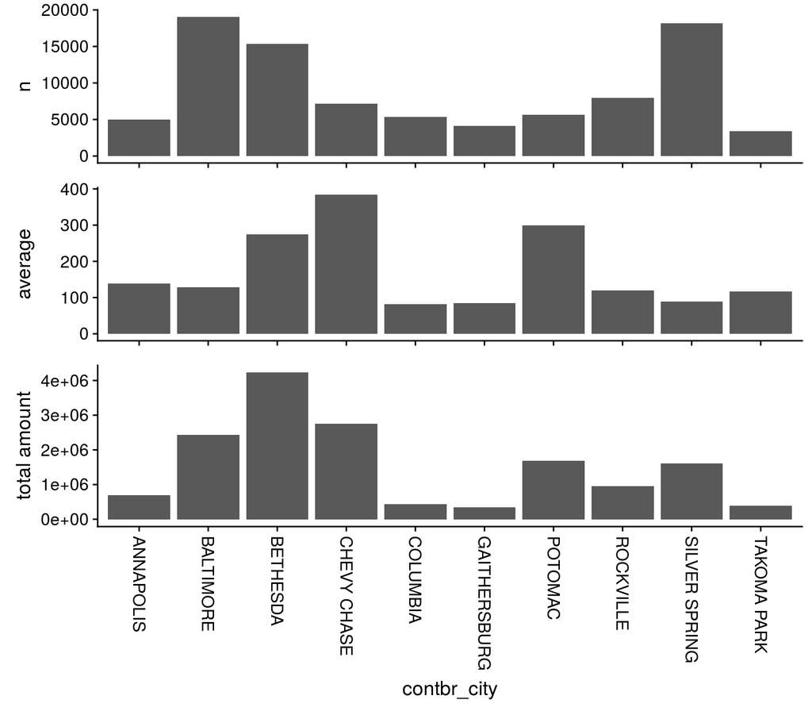

Of these cities, Baltimore has by far the largest population. But the population seems unrelated to the number of contributions. The large number of contributions from smaller municipalities like Silver Spring and Bethesda may be explained by these being suburbs of Washington, DC. thus being home to more than politically involved persons and organizations than other communities of similar size. This becomes even more visible when looking at the total amount contributed.

#### Number of contributions by zip code

This can be broken down further by examining the zip code. As suggested by the first project review, a heatmap shows where contributions are mainly made:

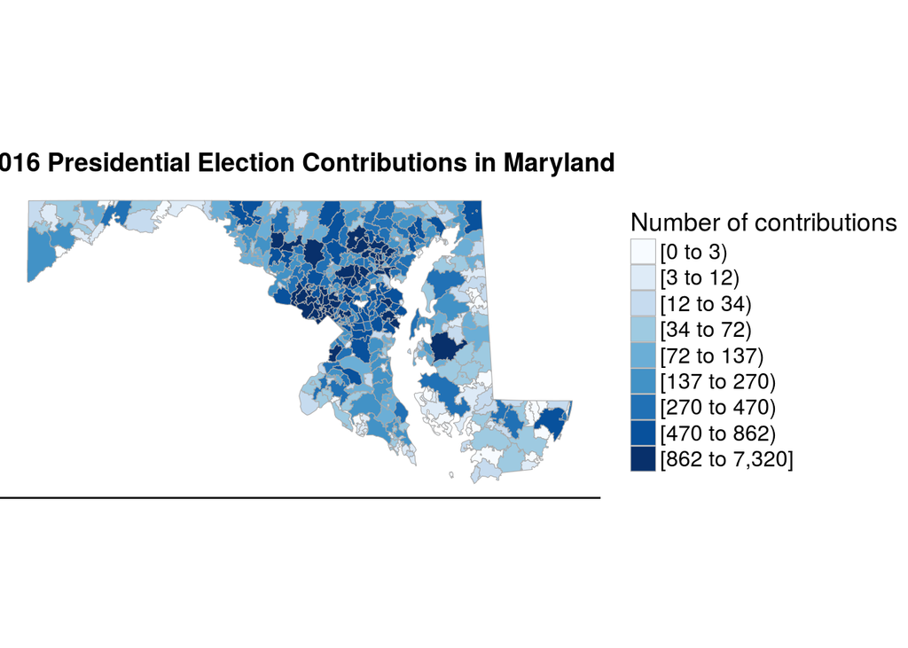

#### Average amount contributed by zip code

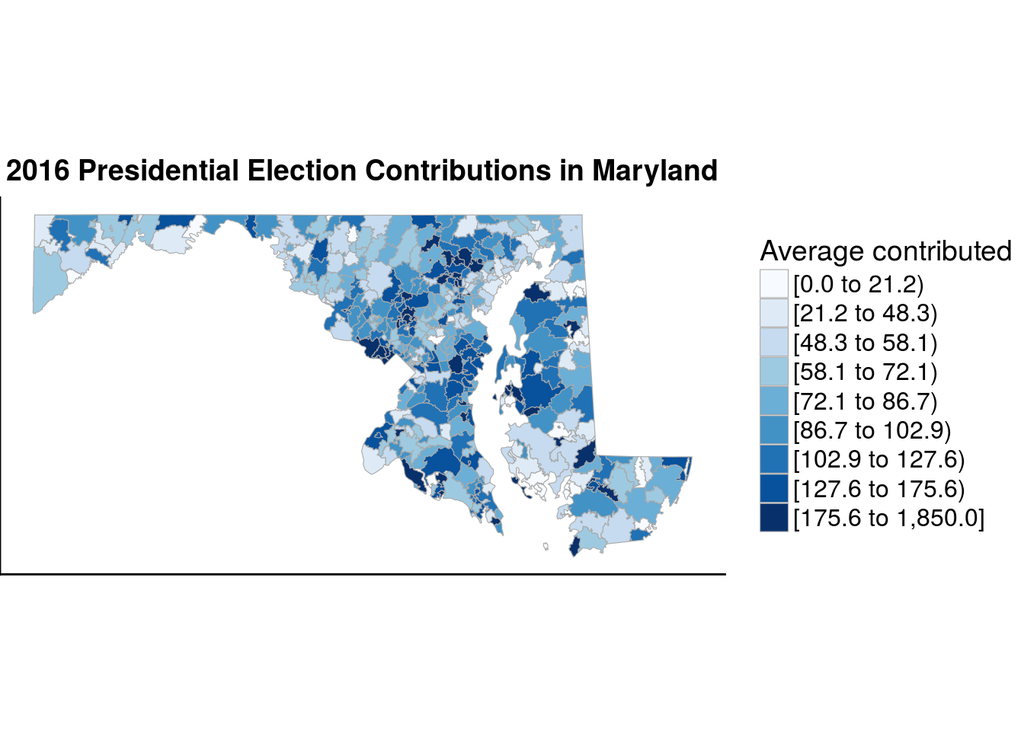

#### Total amount contributed by zip code

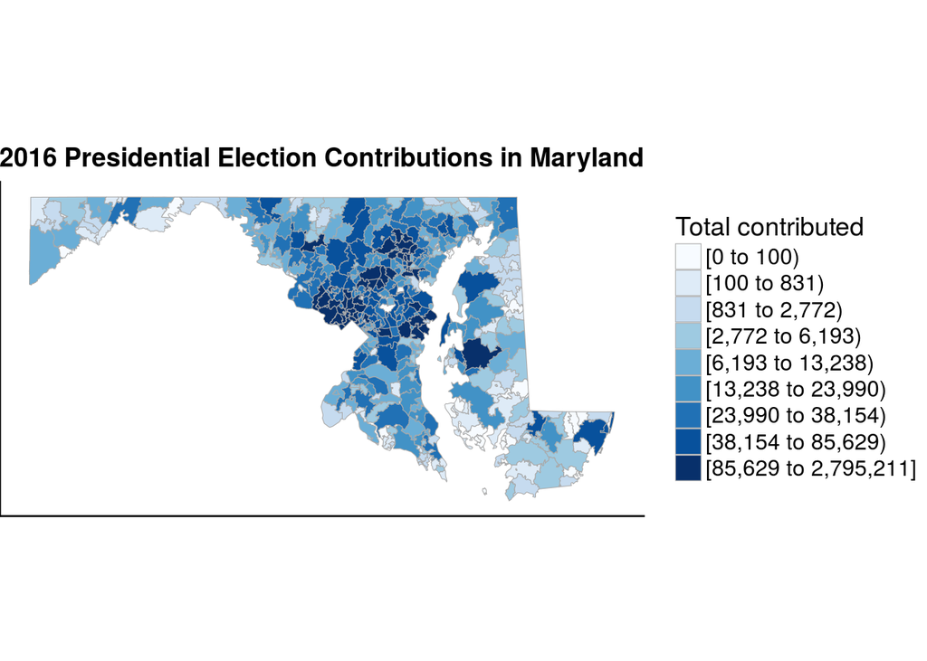

#### Top 10 contributions

Lets find out who donated most:

```
## # A tibble: 37,828 x 2
##                                                                      contbr_nm
##                                                                         <fctr>
##  1                                                          MCWILLIAMS, ROBERT
##  2                                                               COHEN, HOWARD
##  3                                                                BECKER, ERIN
##  4                                                       LEONARD, HUGH JEFFREY
##  5                                                           NEUBERGER, YEHUDA
##  6                                                          SWEET, CHAD C. MR.
##  7                                                         BAINUM, JANE L. MS.
##  8 INTERNATIONAL UNION OF PAINTERS AND ALLIED TRADES POLITICAL ACTION TOGETHER
##  9                                                             GLUECK, KENNETH
## 10                                                        KUMIN, PHILIP A. MR.
## # ... with 37,818 more rows, and 1 more variables:
## #   total.amount.contributed <dbl>
```

Lets check if the top contributors invested in multiple candidates. First, check if they contributed multiple times at all:

```
## # A tibble: 10 x 3
##                                                                      contbr_nm
##                                                                         <fctr>
##  1                                                          MCWILLIAMS, ROBERT
##  2                                                               COHEN, HOWARD
##  3                                                                BECKER, ERIN
##  4                                                       LEONARD, HUGH JEFFREY
##  5                                                           NEUBERGER, YEHUDA
##  6                                                          SWEET, CHAD C. MR.
##  7                                                         BAINUM, JANE L. MS.
##  8 INTERNATIONAL UNION OF PAINTERS AND ALLIED TRADES POLITICAL ACTION TOGETHER
##  9                                                             GLUECK, KENNETH
## 10                                                        KUMIN, PHILIP A. MR.
## # ... with 2 more variables: total.amount.contributed <dbl>, n <int>
```

```
## # A tibble: 10 x 3
##                                                                      contbr_nm
##                                                                         <fctr>
##  1                                                          MCWILLIAMS, ROBERT
##  2                                                               COHEN, HOWARD
##  3                                                                BECKER, ERIN
##  4                                                       LEONARD, HUGH JEFFREY
##  5                                                           NEUBERGER, YEHUDA
##  6                                                          SWEET, CHAD C. MR.
##  7                                                         BAINUM, JANE L. MS.
##  8 INTERNATIONAL UNION OF PAINTERS AND ALLIED TRADES POLITICAL ACTION TOGETHER
##  9                                                             GLUECK, KENNETH
## 10                                                        KUMIN, PHILIP A. MR.
## # ... with 2 more variables: total.amount.contributed <dbl>, n_cand <int>
```

Thus, while some of the top-ten contributors stayed with their candidate during the whole election process, some switched (maybe after their first candidate dropping out) and one contributed to 5 different campaigns.

### Amounts contributed

Lets investigate the amounts of the individual donations.

```
##    Min. 1st Qu.  Median    Mean 3rd Qu.    Max.
## -5400.0    18.0    35.0   133.3   100.0 10800.0
```

So the median donation is $35. But there are also negative contributions. Lets check if we can learn about this from the notes in the data.

#### Negative contributions

```
## # A tibble: 8 x 2
##                            receipt_desc     n
##                                  <fctr> <int>
## 1     * REATTRIBUTED TO AMRUTA FERNBACH     1
## 2    * REATTRIBUTED TO KATHLEEN PEACOCK     1
## 3       * REATTRIBUTED TO MIRIAM SCHECK     1
## 4               REATTRIBUTION TO SPOUSE    48
## 5      REDESIGNATION TO CRUZ FOR SENATE    22
## 6              REDESIGNATION TO GENERAL   136
## 7 REDESIGNATION TO PRESIDENTIAL GENERAL     1
## 8                                Refund  1360
```

Of the ~2000 negative contributions, 1360 have been refunded. By inspecting the respective entries in the `contribution` table, one can see that this happens quite often for candidates which cancelled their campaigns early, for example Ted Cruz. Of the others, some have been re-designated to the general election campaign, others re-attributed to the spouse of the respective contributor. I guess that the latter brings some tax advantage or so, and would like to read more on the topic. But for now we look into the non-negative contributions and drop the others.

#### Amounts of individual contributions

Can we get more from a histogram?

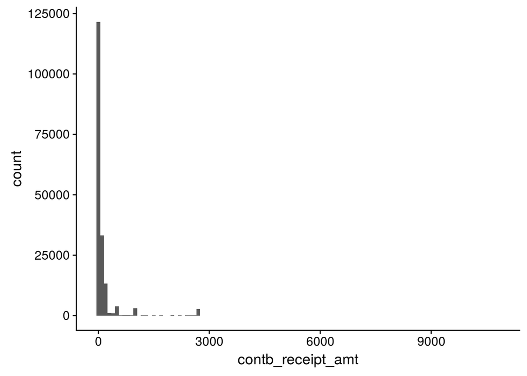

This is rather hard to analyse, because there are so many contributions below $200. Lets use a different scale for the y-axis to improve the histograms shape and see more details in larger contributions.

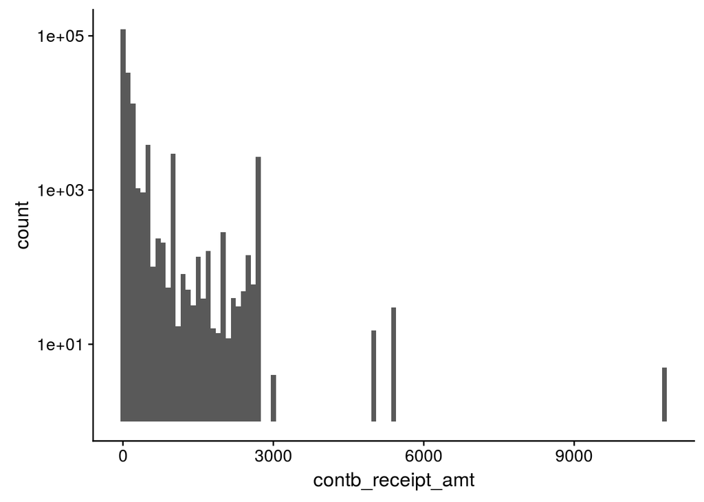

#### By state

This dataset should only contain contributions from Maryland, but lets confirm this.

```
##     MD
## 181271
```

Yes, indeed.

### Per party and candidate

Lets investigate differences by party.

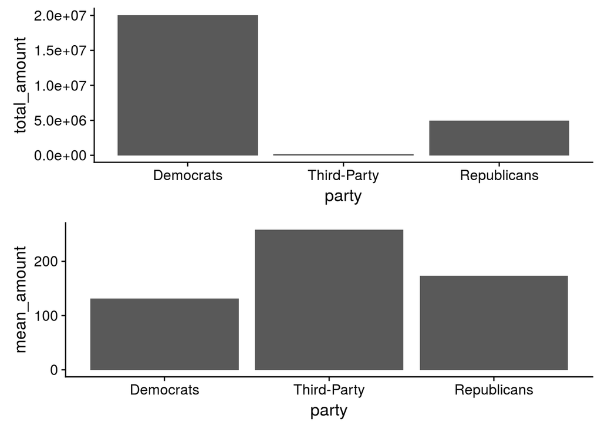

### Compare Hillary Clinton, Bernie Sanders and other Democrats

Lets have a look into different candidates of the same party. As we have seen, Hillary Clinton received the largest amount of contributions. But can we see any more patterns?

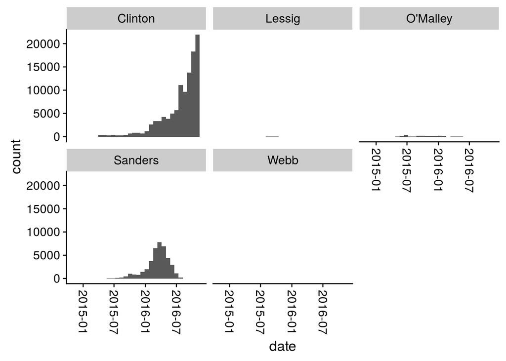

Of the Democrats’ candidates, only Clinton and Sanders received noteworthy contributions. So lets compare these two and consider again the dates for the primary and general election. Also, add markers for the end of their campaigns.

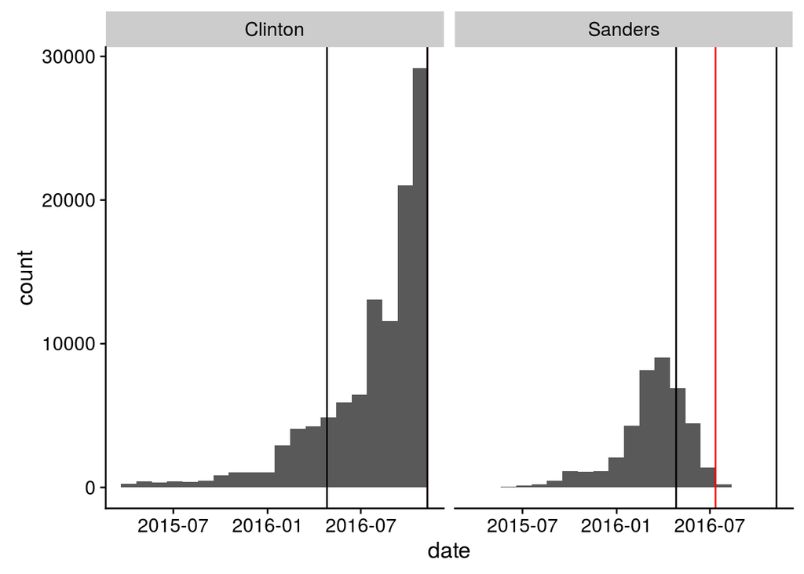

Lets compare individual contributions by candidate and amount.

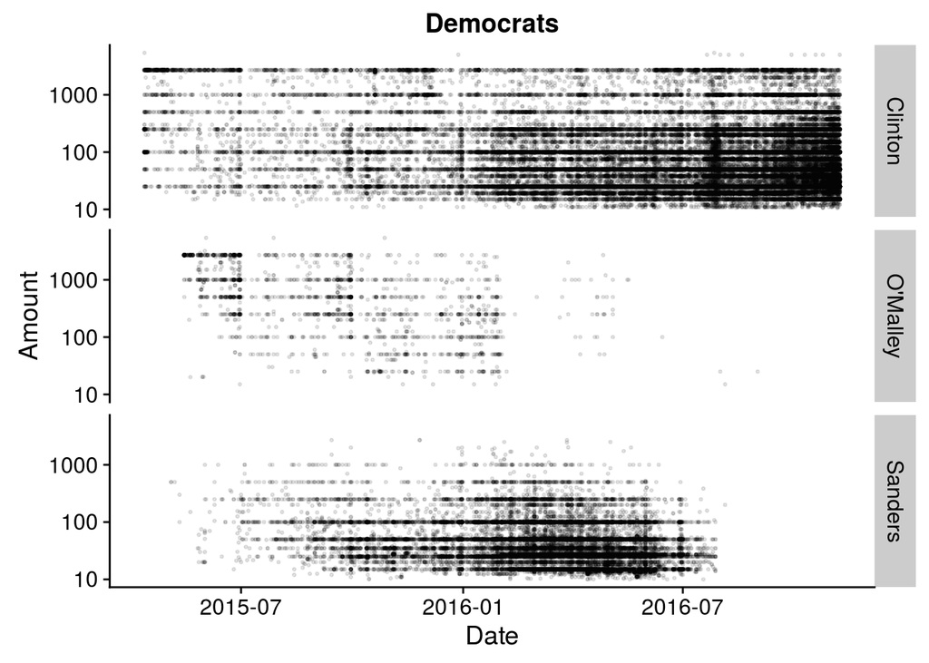

### Compare Trump and last other Republican Candidates.

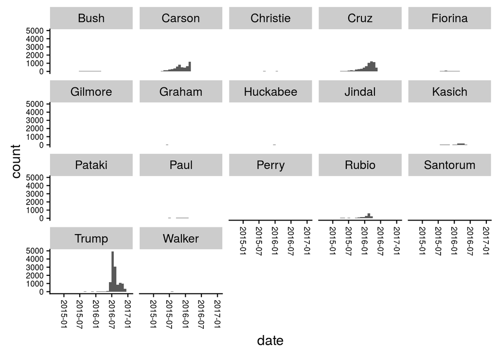

Also here more detail:

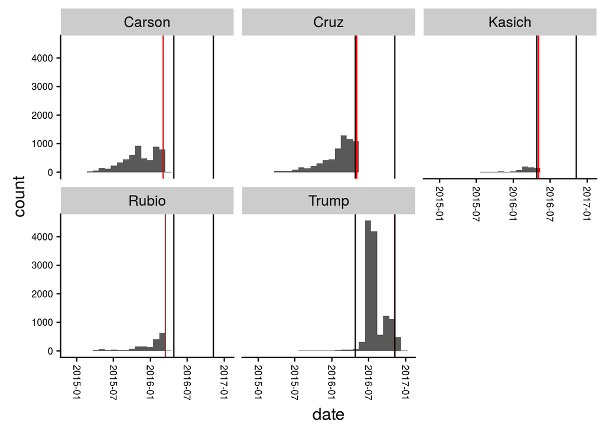

Similar to the Democrat candidates, the contributions increase when the primaries get under way. Donald Trumps campaign seems to make an exception. Prior to the primary, there are just a couple of contributions from Maryland. The number of contributions jump starts once he got the Republican Party ticket.

Lets compare the amounts contributed to different candidates.

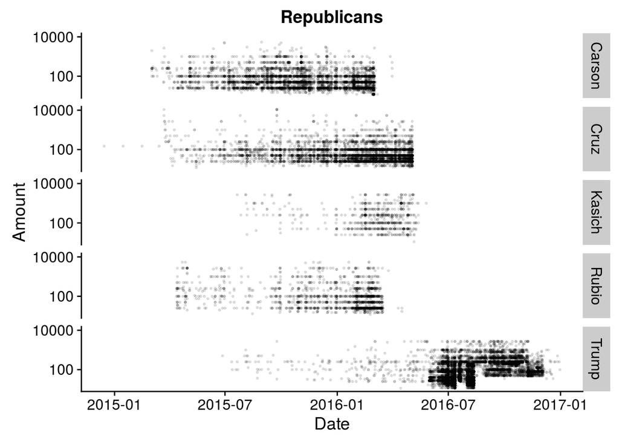

### Occupation and employer

Skipped. Too diverse.

### Others

Finally, check with GGally if there are further relations within the data.

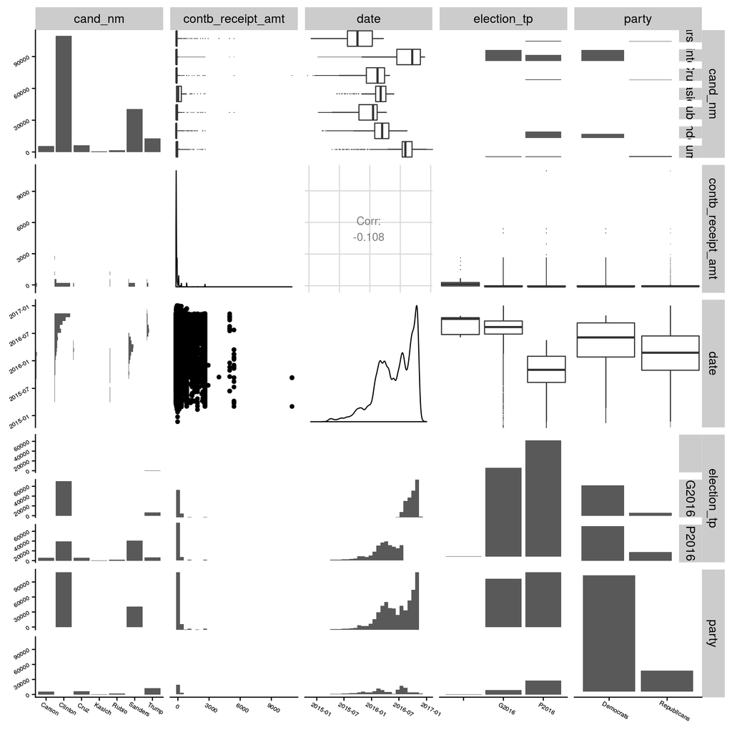

## Final Plots and Summary

### Number of contributions and total amount contributed.

Lets compare the contributions by the total amount contributed and the number of contributions by candidate. For improved visibility, we only look at the top 20 candidates contribution-wise.

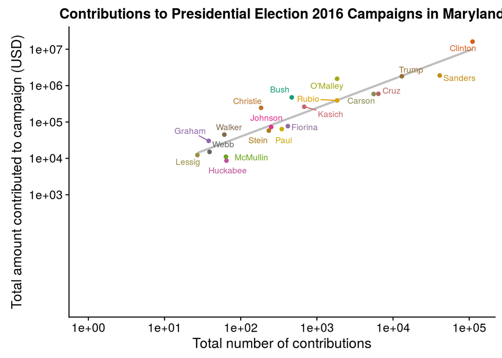

Among the different candidates, the democratic candidates Hillary Clinton and Bernard Sanders received the largest number of contributions. More than 50% of the candidates received less than 1000 contributions.

Hillary Clinton also got the largest total amount of contributions, her outperforming the others by far. Compared to everyone except Donald Trump, this can be explained with the additional general election phase. All other campaigns stopped before that period. After Hillary Clinton, three candidates achieved a similar amount of campaign contributions: Bernie Sanders, Donald Trump and Martin O’Malley. The latter is somewhat surprisingly, because he dropped out early during the primary. But as a former mayor of Baltimore he probably had strong support in Maryland. This is shown by the data, which is exclusively contributions from Maryland.

### Amounts contributed over time (Republican Candidates)

Because the primary process was quite different and candidate selection was independent between Democrats and Republicans, I feel it is necessary to see this in two separate plots. Lets start with the Republicans. We include the candidates which dropped out last and Ben Carson, who used to act as head of Jon Hopkins hospital in Baltimore.

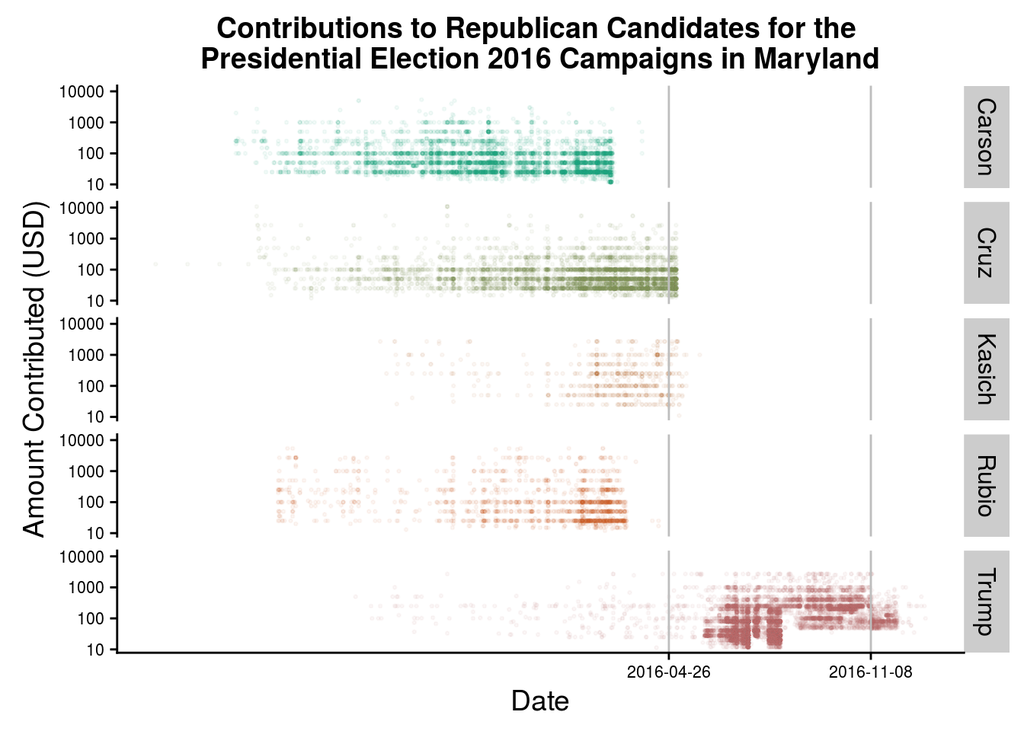

What is most striking in this graph is the poor support for Donald Trump’s campaign prior to the primary election. Only after that, he received considerable financial support. Further looking into the contributions to hist campaign, after a certain date there are no more small contributions, which used to be quite strong before that.

### Amounts contributed over time (Democrat Candidates)

For the candidates of the democratic party, we look only on the top candidates. Although Martin O’Malley dropped out early, he is included here because as former mayor of Baltimore he might have had more support in Maryland than elsewhere in the US.

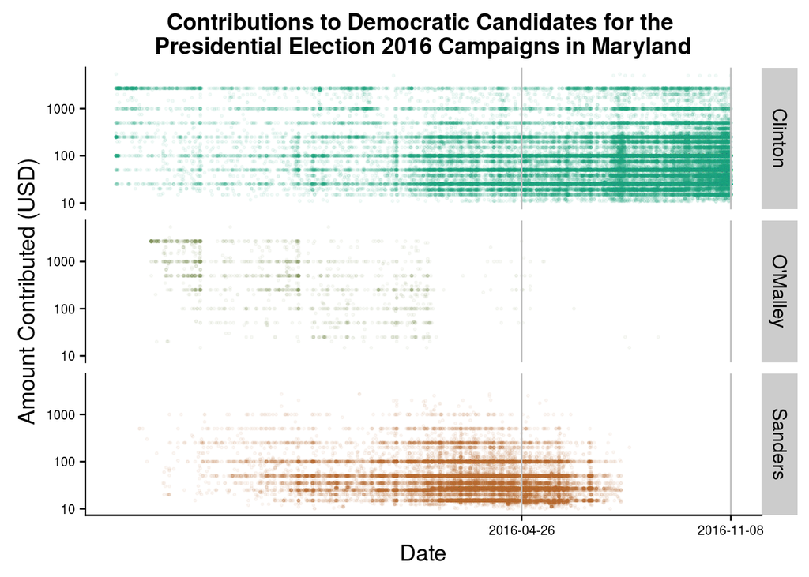

Compared to the other candidates (also republican), Hillary Clinton had many high-amount contributions from the beginning of the election period throughout the end.

Martin O’Malley, the former Baltimore mayor, also had strong support from high-amount contributors, but probably not outside of Maryland.

Bernie Sander’s campaign contributions started relatively late. Compared to other democratic candidates, his campaign had almost no high-amount contributions (in Maryland). The data indicates that his supporters have less money available to spend on political campaigns.

Hillary Clinton won the primary and general election in Maryland, which is confirmed by the contribution support. Having continuous contributions in both large and small amounts seems allow to pursue the campaign until the end. This can also be interpreted as having support from a broader part of the society than for the other candidates.

## Reflection

This project was really interesting. I liked exploring the data from scratch, without any prior knowledge about the subject. OK, we follow the news on the US presidential elections – I have a general idea how the political system in the US works – but I had no clue about the role contributions play in the campaigning process. The idea that you support a candidate rather than a party is strange to me. So after all, Americans invest a lot of money with a high risk for the respective candidate’s failure. So what is the point if your candidate wins? Do you actually get anything in return for your money?

What I found hard when working with this dataset was to determine valuable data. Many variables seem interesting at first glance, but in the end this dataset boils down to the candidate name, the date of the contribution and amount which has been contributed. Then there is a vast number of republican candidates which played no major role and dropped out early. But to see patterns, some of these need to be included. It was hard for me to judge where to draw the line, which candidates to include and which not. Also some of the variables, like employer or occupation of the contributor are just too diverse.

I got a lot of practical experience with shaping graphs using ggplot. What was new and quite helpful are the ggrepel and ggthemes libraries and how to create color palettes using the color brewer thingy.

Given more time, I’d like to see if the patterns found for the Maryland dataset generalize for the whole US:

- Was overall financial support for Donald Trump was larger than for Hillary Clinton?
- Did support for Donald Trump start only after all other republican candidates have been out of the race?
- Did candidates have more financial support in their home states or places where they have been active before (like O’Malley and Carson in Baltimore)?